# HOTEL HR PEOPLE ANALYTICS

### Hotel Analysis from a People Analytics perspective.

This project will try to emulate HR analytics to continue practicing my analytical skills. Also, with this project, I want to strengthen my knowledge in *MySql* *and SQL*. I will use *Python* and *Power BI* for the data analysis.

I will start with doing a little of data engineering to design the databases I am going to work with. I will use *Figma* to draft the databases and the relationships between each other. Then I will fill the databases with the data, and later I will start the data analysis.

### 1. Import libraries

```python
# Libraries to manipulate the data
import pandas as pd
import numpy as np
from datetime import datetime, timedelta
import random
import string
from app_pass import dbpass

# Library to deploy charts with the data
import seaborn as sns
import matplotlib.pyplot as plt

# Statmodels for predictions
import statsmodels.api as sm
import statsmodels.formula.api as smf

# Connect to our MySQL database
import mysql.connector
from sqlalchemy import create_engine


# This is to ignore warnings.
import warnings
warnings.filterwarnings('ignore')
```

### 2. Working with our databases

Previously, I created the databases I was going to work with. Because part of the data was difficult to create randomly, I downloaded the databases into an *.xlsx* file and worked with it.

I called the file *hotel_hranalytics.xlsx*, so now it's time to start working with it.

##### 2.1 Employees Table

```python
# Let's load our databases
df_rawemp = pd.read_excel('../hotel_hranalytics/hotel_hranalytics.xlsx', sheet_name='Employees', converters={'emp_id':str})

df_rawemp.head()
```

|  | emp_id | Name | Surname | Birthday | Age | Gender | on_license | hotel_id |
| --- | --- | --- | --- | --- | --- | --- | --- | --- |
| 0 | 3272 | James | Smith | 1957-08-09 | 67 | M | 0 | FUESSP |
| 1 | 3074 | John | Johnson | 1981-11-19 | 42 | M | 0 | FUESSP |
| 2 | 6627 | Robert | Williams | 1983-10-15 | 41 | M | 0 | FUESSP |
| 3 | 420 | Michael | Brown | 1976-04-05 | 48 | M | 0 | FUESSP |
| 4 | 4856 | William | Jones | 1968-11-20 | 55 | M | 0 | FUESSP |

#### 2.2 Hotels Table

```python
df_rawht = pd.read_excel('../hotel_hranalytics/hotel_hranalytics.xlsx', sheet_name='Hotels')

df_rawht.head()
```

|  | hotel_id | Name | Location | Opening | Stars | Budget |
| --- | --- | --- | --- | --- | --- | --- |
| 0 | FUESSP | Sandy Shores Park | 28 03 18.9N-14 19 21.4W | 2001-03-05 | 4 | 350000000 |
| 1 | TFNOBH | Ocean Breeze Haven | 28 05 56.5N-16 44 54.6W | 1998-10-05 | 5 | 550000000 |
| 2 | ACECWR | Coral Wave Resort | 28 51 25.9N-13 47 48.7 W | 2000-05-05 | 5 | 480000000 |

#### 2.3 Hotels Composition Table

```python
df_rawhtcomp = pd.read_excel('../hotel_hranalytics/hotel_hranalytics.xlsx', sheet_name='Hotel_Composition')

df_rawhtcomp.head()
```

|  | hc_id | Department | Active_employees | Emp_with_license | Total_employees | hotel_id |
| --- | --- | --- | --- | --- | --- | --- |
| 0 | REFUESSP | Reception_Reservations | 11 | 1 | 12 | FUESSP |
| 1 | FLFUESSP | Floors_Laundry | 35 | 3 | 38 | FUESSP |
| 2 | KIFUESSP | Kitchen | 35 | 3 | 38 | FUESSP |
| 3 | BAFUESSP | Bar_Restaurant | 31 | 7 | 38 | FUESSP |
| 4 | ANFUESSP | Animation | 11 | 1 | 12 | FUESSP |

#### 2.4 Employees Wages Table

```python
df_rawempwages = pd.read_excel('../hotel_hranalytics/hotel_hranalytics.xlsx', sheet_name='Employees_wages')

df_rawempwages.head()
```

|  | emp_wag_id | Price_$_Hour | Hours_worked | Work_overtime | Ovh$_75% | Gross_pay | Deductions_3% | Total_Payment | emp_id | hotel_id | hc_id | Payment_date |
| --- | --- | --- | --- | --- | --- | --- | --- | --- | --- | --- | --- | --- |
| 0 | 3272REFUESSP | 14 | 129 | 4 | 10.50 | 1848.00 | 55.4400 | 1792.5600 | 3272 | FUESSP | REFUESSP | 2024-01-29 |
| 1 | 3074REFUESSP | 14 | 143 | 3 | 10.50 | 2033.50 | 61.0050 | 1972.4950 | 3074 | FUESSP | REFUESSP | 2024-01-29 |
| 2 | 6627REFUESSP | 18 | 135 | 4 | 13.50 | 2484.00 | 74.5200 | 2409.4800 | 6627 | FUESSP | REFUESSP | 2024-01-29 |
| 3 | 420REFUESSP | 19 | 121 | 11 | 14.25 | 2455.75 | 73.6725 | 2382.0775 | 420 | FUESSP | REFUESSP | 2024-01-29 |
| 4 | 4856REFUESSP | 14 | 132 | 7 | 10.50 | 1921.50 | 57.6450 | 1863.8550 | 4856 | FUESSP | REFUESSP | 2024-01-29 |

#### 2.5 Workforce Composition Table

```python
df_rawworkforce = pd.read_excel('../hotel_hranalytics/hotel_hranalytics.xlsx', sheet_name='Workforce_Composition')

df_rawworkforce.head()
```

|  | wkc_id | Department | Position | years_at_position | Entry_date | years_working | Staff | emp_id | hotel_id | hc_id |
| --- | --- | --- | --- | --- | --- | --- | --- | --- | --- | --- |
| 0 | 3272FUESSP | Reception_Reservations | Staff | 1 | 2023-09-26 | 1 | 0 | 3272 | FUESSP | REFUESSP |
| 1 | 3074FUESSP | Reception_Reservations | Staff | 1 | 2023-04-29 | 1 | 0 | 3074 | FUESSP | REFUESSP |
| 2 | 6627FUESSP | Reception_Reservations | 3rd_Command | 4 | 2014-01-17 | 10 | 7 | 6627 | FUESSP | REFUESSP |
| 3 | 420FUESSP | Reception_Reservations | 3rd_Command | 3 | 2012-10-25 | 12 | 7 | 420 | FUESSP | REFUESSP |
| 4 | 4856FUESSP | Reception_Reservations | Staff | 1 | 2023-06-18 | 1 | 0 | 4856 | FUESSP | REFUESSP |

#### 2.6 dtypes Testing

I decided to combine all the tables into one big data frame to visualize all the data types each column has instead of using the dytpes command for testing each table. This is the only purpose of the table, and it won't be used in further analyses.

```python
# If I needed let's put all together
df_combined = pd.concat([df_rawemp, df_rawht, df_rawhtcomp, df_rawworkforce, df_rawempwages])

df_combined.dtypes
```

```
emp_id                       object
Name                         object
Surname                      object
Birthday             datetime64[ns]
Age                         float64
Gender                       object
on_license                  float64
hotel_id                     object
Location                     object
Opening                      object
Stars                       float64
Budget                      float64
hc_id                        object
Department                   object
Active_employees            float64
Emp_with_license            float64
Total_employees             float64
wkc_id                       object
Position                     object
years_at_position           float64
Entry_date           datetime64[ns]
years_working               float64
Staff                       float64
emp_wag_id                   object
Price_$_Hour                float64
Hours_worked                float64
Work_overtime               float64
Ovh$_75%                    float64
Gross_pay                   float64
Deductions_3%               float64
Total_Payment               float64
Payment_date         datetime64[ns]
dtype: object
```

After the dtypes testing, we can visualize that some columns needed to change their data type. The next step will be emphasized to correct those data types, in accordance with the ones that were established in our Figma sketch.

#### 2.7 Fixing columns dtype

```python
# Employees Table
df_rawemp[['Age', 'on_license']].apply(pd.to_numeric)
df_rawemp[['hotel_id']].astype('str')

# Hotels Table
df_rawht['Stars'].apply(pd.to_numeric)
df_rawht[['hotel_id']].astype('str')
df_rawht.rename(columns={'Stars': 'Stars_type'}, inplace=True)

# Hotel Composition Table
df_rawhtcomp[['Active_employees', 'Emp_with_license', 'Total_employees']].apply(pd.to_numeric)
df_rawhtcomp[['hc_id', 'hotel_id']].astype('str')

# Workforce Composition Table
df_rawworkforce[['years_at_position', 'years_working', 'Staff']].apply(pd.to_numeric)
df_rawworkforce[['wkc_id', 'emp_id', 'hotel_id', 'hc_id']].astype('str')

# Employees Wages Table
df_rawempwages[['emp_wag_id', 'emp_id', 'hotel_id',	'hc_id']].astype('str')
df_rawempwages[['Price_$_Hour']].apply(pd.to_numeric)
df_rawempwages.rename(columns={'Ovh$_75%': 'Ovh$_75', 'Deductions_3%': 'Deductions_3'}, inplace=True)
```

It was necessary to correct a few column names in order to be similar to the ones created in the *MySQL database.*

Let's proceed to check if all the data is correct and fix all minor errors that are required.

```python
df_rawemp.dtypes
```

```
emp_id                object
Name                  object
Surname               object
Birthday      datetime64[ns]
Age                    int64
Gender                object
on_license             int64
hotel_id              object
dtype: object
```

```python
df_rawhtcomp.dtypes
```

```
hc_id               object
Department          object
Active_employees     int64
Emp_with_license     int64
Total_employees      int64
hotel_id            object
dtype: object
```

```python
df_rawworkforce = df_rawworkforce.rename(columns={'Position': 'Positions'})
df_rawworkforce.dtypes
```

```
wkc_id                       object
Department                   object
Positions                    object
years_at_position             int64
Entry_date           datetime64[ns]
years_working                 int64
Staff                         int64
emp_id                        int64
hotel_id                     object
hc_id                        object
dtype: object
```

```python
df_rawempwages.dtypes
```

```
emp_wag_id               object
Price_$_Hour              int64
Hours_worked              int64
Work_overtime             int64
Ovh$_75                 float64
Gross_pay               float64
Deductions_3            float64
Total_Payment           float64
emp_id                    int64
hotel_id                 object
hc_id                    object
Payment_date     datetime64[ns]
dtype: object
```

```python
#First we let's check for missing values
missing_values = df_rawemp.isnull().sum()
print('Number of missing values: ', missing_values)
```

```
Number of missing values:  emp_id        0
Name          0
Surname       0
Birthday      0
Age           0
Gender        0
on_license    0
hotel_id      0
dtype: int64
```

### 3.1 Let *visualizations* show what the data has to told us.

Let's begin with something simple. How are our employees distributed by gender?

To answer this question we will use the *Employees* table.

```python
# Let's work with the gender column but firs let's create a variable with the lenght of our database
emp_length = len(df_rawemp)
print('The total of registries we have at the Employees table is: ', emp_length)
```

```
The total of registries we have at the Employees table is:  505
```

```python
# Counting the values by the Gender column
emp_gender = df_rawemp['Gender'].value_counts()
print(emp_gender)
```

```
Gender
M    267
F    238
Name: count, dtype: int64
```

##### 3.1.a Time to visualize the Gender data

To visualize the gender distribution I will use a **pie chart.**

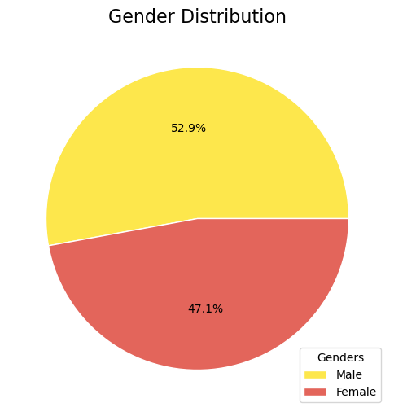

```python
# Preparing the data
colors = plt.get_cmap('Blues')(np.linspace(0.2, 0.7, len(emp_gender)))
labels = 'Male', 'Female'

# Creating the PIE CHART
fig, ax = plt.subplots(figsize=(6, 8))
ax.pie(emp_gender, colors=['#FDE74C', '#E3655B'], autopct='%1.1f%%', center=(4, 4), wedgeprops={"linewidth": 1, "edgecolor": "white"})
ax.legend(labels, loc='lower right', title='Genders')
ax.set_title('Gender Distribution', fontsize=16)

plt.show()
```

The data shows us the distribution by gender in our three hotels. The employees are distributed, and we have a total of **238 female employees**, representing **47,1%** of the total workforce. And for the **males**, we have **267 employees**, **52,9%** of the total workforce.

##### 3.1.b Let's analyze the gender distribution by Departments and Hotels

In order to calculate the gender distribution according to the different departments, it will be necessary to combine the tables of *"Employees"* and *"Workforce Composition"*. I will use the column *'emp_id'* to combine both tables.

```python
# Preparing the data
df_rawworkforce['emp_id'] = df_rawworkforce['emp_id'].astype('str')
emp_gender_by_dep = pd.merge(df_rawemp, df_rawworkforce, on='emp_id', how='inner')
emp_gender_by_dep.head()
```

|  | emp_id | Name | Surname | Birthday | Age | Gender | on_license | hotel_id_x | wkc_id | Department | Positions | years_at_position | Entry_date | years_working | Staff | hotel_id_y | hc_id |
| --- | --- | --- | --- | --- | --- | --- | --- | --- | --- | --- | --- | --- | --- | --- | --- | --- | --- |
| 0 | 3272 | James | Smith | 1957-08-09 | 67 | M | 0 | FUESSP | 3272FUESSP | Reception_Reservations | Staff | 1 | 2023-09-26 | 1 | 0 | FUESSP | REFUESSP |
| 1 | 3074 | John | Johnson | 1981-11-19 | 42 | M | 0 | FUESSP | 3074FUESSP | Reception_Reservations | Staff | 1 | 2023-04-29 | 1 | 0 | FUESSP | REFUESSP |
| 2 | 6627 | Robert | Williams | 1983-10-15 | 41 | M | 0 | FUESSP | 6627FUESSP | Reception_Reservations | 3rd_Command | 4 | 2014-01-17 | 10 | 7 | FUESSP | REFUESSP |
| 3 | 420 | Michael | Brown | 1976-04-05 | 48 | M | 0 | FUESSP | 420FUESSP | Reception_Reservations | 3rd_Command | 3 | 2012-10-25 | 12 | 7 | FUESSP | REFUESSP |
| 4 | 4856 | William | Jones | 1968-11-20 | 55 | M | 0 | FUESSP | 4856FUESSP | Reception_Reservations | Staff | 1 | 2023-06-18 | 1 | 0 | FUESSP | REFUESSP |

```python
# Let's drop the columns we are not going to use
emp_gender_by_dep.drop(columns=['Name', 'Surname', 'Birthday', 'wkc_id', 'years_at_position', 'years_working', 'Entry_date', 'hotel_id_y', 'hc_id', 'Staff'], inplace=True)
emp_gender_by_dep.head()
```

|  | emp_id | Age | Gender | on_license | hotel_id_x | Department | Positions |
| --- | --- | --- | --- | --- | --- | --- | --- |
| 0 | 3272 | 67 | M | 0 | FUESSP | Reception_Reservations | Staff |
| 1 | 3074 | 42 | M | 0 | FUESSP | Reception_Reservations | Staff |
| 2 | 6627 | 41 | M | 0 | FUESSP | Reception_Reservations | 3rd_Command |
| 3 | 420 | 48 | M | 0 | FUESSP | Reception_Reservations | 3rd_Command |
| 4 | 4856 | 55 | M | 0 | FUESSP | Reception_Reservations | Staff |

```python
# Checking for missing values
gender_by_dep_missing_values = emp_gender_by_dep.isnull().sum()
print('The missing values are: ', gender_by_dep_missing_values)
```

```
The missing values are:  emp_id        0
Age           0
Gender        0
on_license    0
hotel_id_x    0
Department    0
Positions     0
dtype: int64
```

##### It's time to visualize our data, gender distribution by *Hotel* and *Departments*

```
   hotel_id_x              Department Gender  Count
0      ACECWR                      3R      F      3
1      ACECWR               Animation      F     12
2      ACECWR          Bar_Restaurant      F     38
3      ACECWR          Floors_Laundry      M     38
4      ACECWR                 Kitchen      F      8
5      ACECWR                 Kitchen      M     30
6      ACECWR                   Other      F      6
7      ACECWR  Reception_Reservations      M     12
8      ACECWR                     SPA      F      6
9      ACECWR      Technical_Services      F     12
10     FUESSP                      3R      F      4
11     FUESSP               Animation      F     12
12     FUESSP          Bar_Restaurant      F     31
13     FUESSP          Bar_Restaurant      M      7
14     FUESSP          Floors_Laundry      M     38
15     FUESSP                 Kitchen      M     38
16     FUESSP                   Other      F      6
17     FUESSP  Reception_Reservations      M     12
18     FUESSP                     SPA      F      6
19     FUESSP      Technical_Services      F     12
20     TFNOBH                      3R      F      4
21     TFNOBH               Animation      F     12
22     TFNOBH          Bar_Restaurant      F     41
23     TFNOBH          Floors_Laundry      M     39
24     TFNOBH                 Kitchen      M     40
25     TFNOBH                   Other      F      6
26     TFNOBH  Reception_Reservations      M     13
27     TFNOBH                     SPA      F      6
28     TFNOBH      Technical_Services      F     13
```

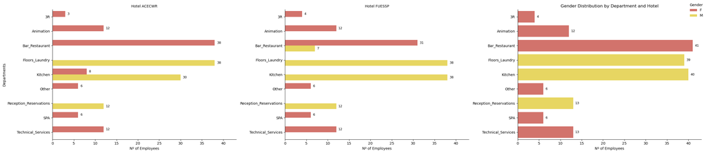

```python
# Preparing the data
gender_dist = emp_gender_by_dep.groupby(['hotel_id_x', 'Department', 'Gender']).size().reset_index()
gender_dist.rename(columns={0: 'Count'}, inplace=True)
print(gender_dist)

# Converting the Count column to numeric
gender_dist['Count'] = gender_dist['Count'].astype('int64')

gender_dist['Count'].dtypes

# Using Seaborn to create a barplot with FacetGrid
grid = sns.FacetGrid(
    gender_dist,
    col='hotel_id_x',
    height=6,
    aspect=1.5,
    sharey=False
)

# Drawing the plot
grid.map_dataframe(
    sns.barplot,
    y='Department',
    x='Count',
    hue='Gender',
    palette=['#E3655B','#FDE74C']
)

# Adding the counts to each bar
for ax in grid.axes.flat:
    for container in ax.containers:
        for bar in container:
            bar_value = bar.get_width()
            if bar_value > 0:
                ax.text(
                    bar_value + 0.5,
                    bar.get_y() + bar.get_height() / 2,
                    f"{int(bar_value)}",
                    ha='left',
                    va='center',
                    fontsize=9,
                    color='black'
                )

# Legend and title
grid.add_legend(title='Gender')
grid.legend.set_loc('upper right')
grid.set_titles('Hotel {col_name}')
grid.set_axis_labels('Nº of Employees', 'Departments')
plt.tight_layout()
plt.title('Gender Distribution by Department and Hotel')

plt.show()
```

##### Gender distribution by *Department*

```
                Department Gender  Count
0                       3R      F     11
1                Animation      F     36
2           Bar_Restaurant      F    110
3           Bar_Restaurant      M      7
4           Floors_Laundry      M    115
5                  Kitchen      F      8
6                  Kitchen      M    108
7                    Other      F     18
8   Reception_Reservations      M     37
9                      SPA      F     18
10      Technical_Services      F     37
```

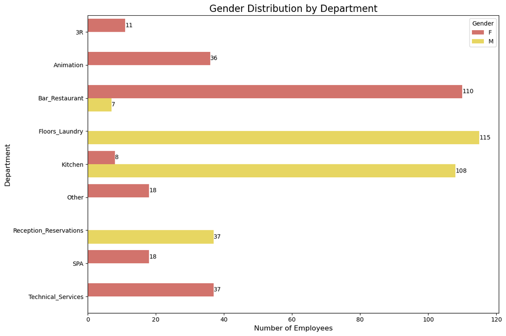

```python
# Preparing the data
gender_by_dep = emp_gender_by_dep.groupby(['Department', 'Gender']).size().reset_index(name='Count')
print(gender_by_dep)

# Creating the barplot
plt.figure(figsize=(12, 8))
ax = sns.barplot(
    data=gender_by_dep,
    x='Count',
    y='Department',
    hue='Gender',
    palette=['#E3655B','#FDE74C'],
    ci=None
)

# Adding the counts to each bar
for container in ax.containers:
    ax.bar_label(container, fmt='%d', label_type='edge', fontsize=10, color='black')

# Displaying the plot
plt.title('Gender Distribution by Department', fontsize=16)
plt.xlabel('Number of Employees', fontsize=12)
plt.ylabel('Department', fontsize=12)
plt.legend(title='Gender')
plt.tight_layout()


plt.show()
```

##### 3.2 Let analyze how our employees are distributed by *Age*

I will create an age range with the purpose of facilitate the analysis

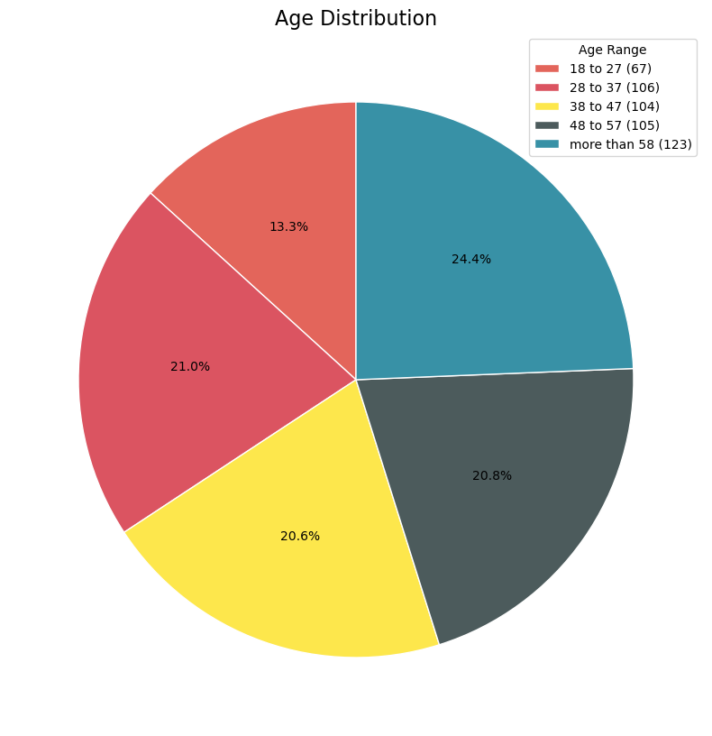

```python
# Creating a function to distribute our employees by age range
def age_range(age):
    if age >= 18 and age <= 27:
        return '18 to 27'
    elif age >= 28 and age <= 37:
        return '28 to 37'
    elif age >= 38 and age <= 47:
        return '38 to 47'
    elif age >= 48 and age <= 57:
        return '48 to 57'
    else:
        return 'more than 58'

# Applying the function to the Age column
emp_age_range = df_rawemp['Age'].apply(lambda x: pd.Series(age_range(x)))

# Creating a new column with the Age Range
df_rawemp['Age_range'] = emp_age_range

# Let's check the distribution of the age range
age_range_count = df_rawemp['Age_range'].value_counts().sort_index()
total_agerange_count = age_range_count.sum()
percentage = (age_range_count / total_agerange_count) * 100

# Creating the Pie Chart
fig, ax = plt.subplots(figsize=(12, 10))
colors = ['#E3655B', '#DB5461', '#FDE74C', '#4C5B5C', '#3891A6']
labels = [f'{age} ({count})' for age, count in zip(age_range_count.index, age_range_count)]
labels_sort = df_rawemp['Age_range'].value_counts().sort_index()
graph_labels = '18 to 27', '28 to 37', '38 to 47', '48 to 57', 'more than 58'

ax.pie(age_range_count, autopct='%1.1f%%', center=(4, 4), wedgeprops={"linewidth": 1, "edgecolor": "white"}, startangle=90, colors=colors)

plt.legend(labels, loc='upper right', title='Age Range')

ax.set_title('Age Distribution', fontsize=16)
```

After separating the employees of the three hotels within the age ranges, the following results were obtained:

Age Range

- 18 to 27 a total of **67** employees that represent a *13,3%*
- 28 to 37 a total of **106** employees that represent a *21%*
- 38 to 47 a total of **104** employees that represent a *20,6%*
- 48 to 57 a total of **105** employees that represent a *20,8%*
- More than 58 a total of **123** employees that represent a *24,4%*

We can see that the majority of our staff members are *above* 28 after looking at the distribution of personnel by age range. 13.3% of our personnel is between the ages of 18 and 27, which indicates that *we need to start updating our workforce*. It is advised that future hiring staff concentrate on this age group.

Let's determine which hotels should begin hiring more younger employees.

```
Age_range  18 to 27  28 to 37  38 to 47  48 to 57  more than 58
hotel_id
ACECWR           17        31        43        38            36
FUESSP           24        35        29        32            46
TFNOBH           26        40        32        35            41
```

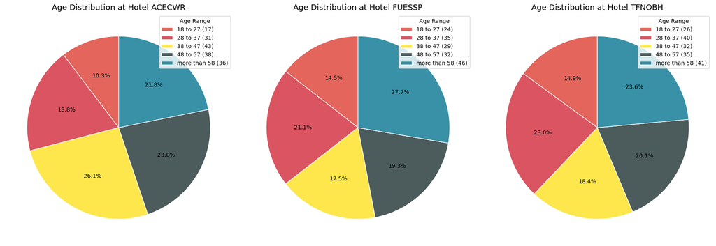

```python
# Age distribution by hotels
agerange_by_hotel = df_rawemp.groupby(['hotel_id', 'Age_range']).size().unstack()
print(agerange_by_hotel)

# Creating the Pie Charts
fig, axs = plt.subplots(1, 3, figsize=(18, 6))

colors = ['#E3655B', '#DB5461', '#FDE74C', '#4C5B5C', '#3891A6']

for i, hotel in enumerate(agerange_by_hotel.index):
    ax = axs[i]
    labelsbyhotel = [f'{age} ({count})' for age, count in zip(age_range_count.index, agerange_by_hotel.loc[hotel])]
    ax.pie(agerange_by_hotel.loc[hotel], autopct='%1.1f%%', center=(4, 4), wedgeprops={"linewidth": 1, "edgecolor": "white"}, startangle=90, colors=colors)
    ax.set_title(f'Age Distribution at Hotel {hotel}', fontsize=14)
    ax.legend(labelsbyhotel, loc='upper right', title='Age Range')

plt.tight_layout()
plt.show()
```

Following an analysis of the age ranges of the three hotels, we have determined that **Sandy Shores Park** has the most elderly staff, with 46 employees aged over 58. Additionally, this hotel has been in business for a shorter period of time thanthe other two hotels. While the staff at **Coral Wave Resort** is fine, it is advised to keep a watch on their group from *38 to 47*, because this is the middle of the age ranges, if they are careless they will end up having the most unbalanced workforce. The hotel with a balanced workforce is **Ocean Breeze Haven**.

Let's figure out the *average age* we have for the hotels. The *average working years* the personnel have. And last, how many employees *on license* does each hotel have?

```python
df_rawemp['Age'].describe().round()
```

```
count    505.0
mean      45.0
std       14.0
min       21.0
25%       33.0
50%       45.0
75%       57.0
max       69.0
Name: Age, dtype: float64
```

```python
# With the purpose to view the hotels names
hotel_names = df_rawht.set_index('hotel_id')['Name']

# Let's check the average age of the employees by hotel
avg_age_byhotel = df_rawemp.groupby('hotel_id')['Age'].mean().round()

# Let's check the average working years of the employees by hotel
avg_working_years = df_rawworkforce.groupby('hotel_id')['years_working'].mean().round()

# To print the names of the hotels in the results
avg_age_byhotel.index = avg_age_byhotel.index.map(lambda x: f"{x} ({hotel_names[x]})")
avg_working_years.index = avg_working_years.index.map(lambda x: f"{x} ({hotel_names[x]})")

# To eliminate the name of the column hotel_id
avg_age_byhotel.index.name = None
avg_working_years.index.name = None

print('The average age of the employees is: ','\n', avg_age_byhotel, '\n\n',
    'The average working years of the employees is: ','\n', avg_working_years, '\n\n',
)
```

```
The average age of the employees is:
 ACECWR (Coral Wave Resort)     45.0
FUESSP (Sandy Shores Park)     45.0
TFNOBH (Ocean Breeze Haven)    44.0
Name: Age, dtype: float64

 The average working years of the employees is:
 ACECWR (Coral Wave Resort)     12.0
FUESSP (Sandy Shores Park)     12.0
TFNOBH (Ocean Breeze Haven)    14.0
Name: years_working, dtype: float64
```

##### 3.3 Analyzing how many of our employees are on license

Now is time to visualize the employees that are on license. Let's figure out If we have a significant number of employees on license.

```python
# Let's check the number of employees with license
emp_on_license = df_rawemp[(df_rawemp['on_license'] == True)].count()
emp_on_license_byhotel = df_rawemp.groupby('hotel_id')['on_license'].sum()
per_emp_on_license = (emp_on_license['on_license'] / emp_length) * 100

# To print the names of the hotels in the results
emp_on_license_byhotel.index = emp_on_license_byhotel.index.map(lambda x: f"{x} ({hotel_names[x]})")

# To eliminate the name of the column hotel_id
emp_on_license_byhotel.index.name = None

print('The number of employees with license is: ','\n', emp_on_license_byhotel, '\n\n',
    'The total employees with license is: ', emp_on_license['on_license'], '\n\n',
    'The percentage of employees with license is: ', per_emp_on_license.round(2), '%'
)
```

```
The number of employees with license is:
 ACECWR (Coral Wave Resort)     28
FUESSP (Sandy Shores Park)     18
TFNOBH (Ocean Breeze Haven)    27
Name: on_license, dtype: int64

 The total employees with license is:  73

 The percentage of employees with license is:  14.46 %
```

```
on_license
0    432
1     73
Name: count, dtype: int64
```

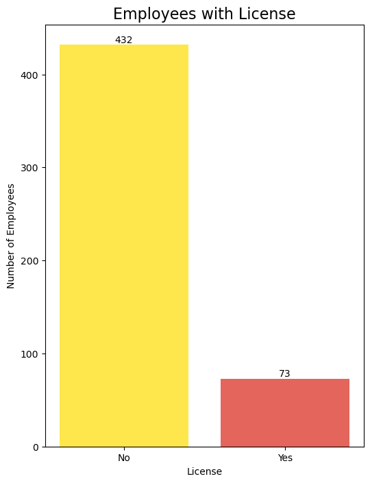

```python
# Preparing the data to visualize the employees with license
on_license_count = df_rawemp['on_license'].value_counts()
print(on_license_count)

# Creating the barplot
fig, ax = plt.subplots(figsize=(6, 8))

labels = 'No', 'Yes'
colors = '#FDE74C', '#E3655B'

ax.bar(labels, on_license_count, color=colors)
ax.bar_label(ax.containers[0], fontsize=10)

plt.title('Employees with License', fontsize=16)
plt.ylabel('Number of Employees')
plt.xlabel('License')
plt.show()
```

From a total of *505 employees,* only 73 are on leave by license; this represents **14,46%** of the total personnel. The company now will have to determine what percentage will be considered serious.

It's time to break down the licenses into the three hotels to visualize which hotel has the most employees on license.

```
on_license    0   1
hotel_id
ACECWR      137  28
FUESSP      148  18
TFNOBH      147  27
```

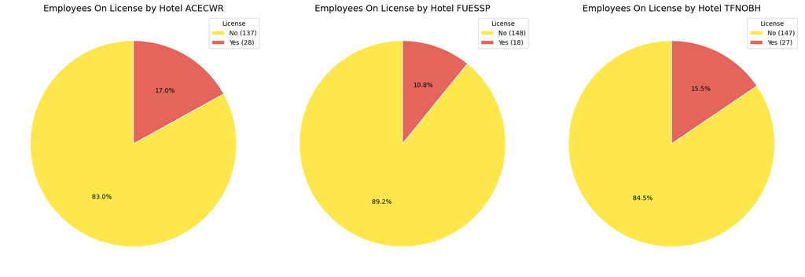

```python
# Preparing the data
onlicense_by_hotel = df_rawemp.groupby(['hotel_id', 'on_license']).size().unstack()
print(onlicense_by_hotel)

# Creating the Pie Charts
fix, axs = plt.subplots(1, 3, figsize=(18, 6))
labels_onlicense = 'No', 'Yes'

for i, hotel in enumerate(onlicense_by_hotel.index):
    ax = axs[i]
    labels2 = [f'{age} ({count})' for age, count in zip(labels_onlicense, onlicense_by_hotel.loc[hotel])]
    ax.pie(onlicense_by_hotel.loc[hotel], autopct='%1.1f%%', center=(4, 4), wedgeprops={"linewidth": 1, "edgecolor": "white"}, startangle=90, colors=['#FDE74C', '#E3655B'])
    ax.set_title(f'Employees On License by Hotel {hotel}', fontsize=14)
    ax.legend(labels2, loc='upper right', title='License')

plt.tight_layout()
plt.show()
```

After breaking down the data, it shows that the *Coral Wave Resort*, with **28** employees, and *Ocean Breeze Haven*, with **27** employees, both are the hotels with more staff on license.

##### 4. Analyzing the Employees Wages Table

We can now examine the annual salary payments since we know how our workforce is composed. I will start by merging the *Employees Wages* table with the *Workforce Composition* table in order to better comprehend our data. This will enable us to filter the data by Positions and Departments.

```python
# Let's work with the employees wages table
# First let merge the workforce composition table with the employees wages table for a better analysis
df_rawempwages['emp_id'] = df_rawempwages['emp_id'].astype('str')
emp_wages_wfc = pd.merge(df_rawempwages, df_rawworkforce, on='emp_id', how='inner')
emp_wages_wfc.head()
```

|  | emp_wag_id | Price_$_Hour | Hours_worked | Work_overtime | Ovh$_75 | Gross_pay | Deductions_3 | Total_Payment | emp_id | hotel_id_x | ... | Payment_date | wkc_id | Department | Positions | years_at_position | Entry_date | years_working | Staff | hotel_id_y | hc_id_y |
| --- | --- | --- | --- | --- | --- | --- | --- | --- | --- | --- | --- | --- | --- | --- | --- | --- | --- | --- | --- | --- | --- |
| 0 | 3272REFUESSP | 14 | 129 | 4 | 10.50 | 1848.00 | 55.4400 | 1792.5600 | 3272 | FUESSP | ... | 2024-01-29 | 3272FUESSP | Reception_Reservations | Staff | 1 | 2023-09-26 | 1 | 0 | FUESSP | REFUESSP |
| 1 | 3074REFUESSP | 14 | 143 | 3 | 10.50 | 2033.50 | 61.0050 | 1972.4950 | 3074 | FUESSP | ... | 2024-01-29 | 3074FUESSP | Reception_Reservations | Staff | 1 | 2023-04-29 | 1 | 0 | FUESSP | REFUESSP |
| 2 | 6627REFUESSP | 18 | 135 | 4 | 13.50 | 2484.00 | 74.5200 | 2409.4800 | 6627 | FUESSP | ... | 2024-01-29 | 6627FUESSP | Reception_Reservations | 3rd_Command | 4 | 2014-01-17 | 10 | 7 | FUESSP | REFUESSP |
| 3 | 420REFUESSP | 19 | 121 | 11 | 14.25 | 2455.75 | 73.6725 | 2382.0775 | 420 | FUESSP | ... | 2024-01-29 | 420FUESSP | Reception_Reservations | 3rd_Command | 3 | 2012-10-25 | 12 | 7 | FUESSP | REFUESSP |
| 4 | 4856REFUESSP | 14 | 132 | 7 | 10.50 | 1921.50 | 57.6450 | 1863.8550 | 4856 | FUESSP | ... | 2024-01-29 | 4856FUESSP | Reception_Reservations | Staff | 1 | 2023-06-18 | 1 | 0 | FUESSP | REFUESSP |

5 rows × 21 columns

With the tables combined, let's drop those columns that we will not use during our analysis.

```python
# Droping the columns we are not going to use
emp_wages_wfc.drop(columns=['hotel_id_y', 'hc_id_y', 'wkc_id', 'years_at_position', 'Entry_date', 'years_working', 'Staff'], inplace=True)
emp_wages_wfc.head()
```

|  | emp_wag_id | Price_$_Hour | Hours_worked | Work_overtime | Ovh$_75 | Gross_pay | Deductions_3 | Total_Payment | emp_id | hotel_id_x | hc_id_x | Payment_date | Department | Positions |
| --- | --- | --- | --- | --- | --- | --- | --- | --- | --- | --- | --- | --- | --- | --- |
| 0 | 3272REFUESSP | 14 | 129 | 4 | 10.50 | 1848.00 | 55.4400 | 1792.5600 | 3272 | FUESSP | REFUESSP | 2024-01-29 | Reception_Reservations | Staff |
| 1 | 3074REFUESSP | 14 | 143 | 3 | 10.50 | 2033.50 | 61.0050 | 1972.4950 | 3074 | FUESSP | REFUESSP | 2024-01-29 | Reception_Reservations | Staff |
| 2 | 6627REFUESSP | 18 | 135 | 4 | 13.50 | 2484.00 | 74.5200 | 2409.4800 | 6627 | FUESSP | REFUESSP | 2024-01-29 | Reception_Reservations | 3rd_Command |
| 3 | 420REFUESSP | 19 | 121 | 11 | 14.25 | 2455.75 | 73.6725 | 2382.0775 | 420 | FUESSP | REFUESSP | 2024-01-29 | Reception_Reservations | 3rd_Command |
| 4 | 4856REFUESSP | 14 | 132 | 7 | 10.50 | 1921.50 | 57.6450 | 1863.8550 | 4856 | FUESSP | REFUESSP | 2024-01-29 | Reception_Reservations | Staff |

```python
# Checking for missing values
new_missing_values = emp_wages_wfc.isnull().sum()
print('Number of missing values: ', new_missing_values)
```

```
Number of missing values:  emp_wag_id       0
Price_$_Hour     0
Hours_worked     0
Work_overtime    0
Ovh$_75          0
Gross_pay        0
Deductions_3     0
Total_Payment    0
emp_id           0
hotel_id_x       0
hc_id_x          0
Payment_date     0
Department       0
Positions        0
dtype: int64
```

4.1 For the first analysis, let's discover the **average price** *per hour* the hotels are paying to their employees. Also, let's figure out the **average hours** the employees work. How much did the hotels pay in salaries over the year?

I will add to the analysis the **average over time hours** worked by the employees. The **total overtime hours** worked by the personnel during the entire year and how much the hotels paid for all those hours.

```python
avg_hour_price = emp_wages_wfc['Price_$_Hour'].mean().round()
avg_hours_worked = emp_wages_wfc['Hours_worked'].mean().round()
emp_wages_wfc['total_paid_NH'] = emp_wages_wfc['Hours_worked'] * emp_wages_wfc['Price_$_Hour']
total_paid_NH = emp_wages_wfc['total_paid_NH'].sum()
avg_OT_hours_worked = emp_wages_wfc['Work_overtime'].mean().round()
total_OT_hours = emp_wages_wfc['Work_overtime'].sum()
emp_wages_wfc['total_paid_OT'] = emp_wages_wfc['Work_overtime'] * emp_wages_wfc['Ovh$_75']
total_paid_OT = emp_wages_wfc['total_paid_OT'].sum()

print('The average  price per hour: ','€', avg_hour_price, '\n\n',
    'The average hours working by our employees is: ', avg_hours_worked, '\n\n',
    'The total SUM we paid for normal hours is: ', '€', total_paid_NH, '\n\n',
    'The average Over Time hours worked by our employees is: ', avg_OT_hours_worked, '\n\n',
    'The total Over Time hours worked by: ', total_OT_hours, '\n\n'
    'The total SUM paid for OverTime hours: ', '€', total_paid_OT
)
```

```
The average  price per hour:  € 15.0

 The average hours working by our employees is:  140.0

 The total SUM we paid for normal hours is:  € 12950211

 The average Over Time hours worked by our employees is:  6.0

 The total Over Time hours worked by:  33501

The total SUM paid for OverTime hours:  € 382709.25
```

With a *Pie chart* we will visualize how the working hours are distributed between normal and overtime.

```
The total hours worked by our employees is:  882410

 Percentage Normal Hours:  96.2

 Percentage Over Time Hours:  3.8
```

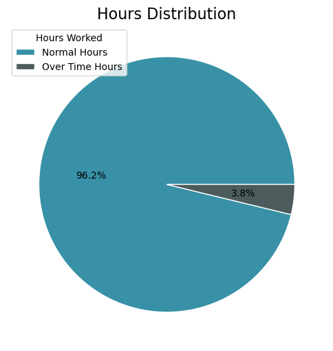

```python
# Let's visualize the percentage of the total hours worked by the employees
# First we need to calculate the total hours worked by the employees
total_hours_worked = emp_wages_wfc['Hours_worked'].sum() + emp_wages_wfc['Work_overtime'].sum()
per_NH = (emp_wages_wfc['Hours_worked'].sum() / total_hours_worked) * 100
per_OTh = (emp_wages_wfc['Work_overtime'].sum() / total_hours_worked) * 100
print('The total hours worked by our employees is: ', total_hours_worked, '\n\n',
      'Percentage Normal Hours: ', per_NH.round(2), '\n\n',
      'Percentage Over Time Hours: ', per_OTh.round(2)
      )

# Now that we have the percentage we can visualize them
hours = [per_NH, per_OTh]
colors = ['#3891A6', '#4C5B5C']
labels = ['Normal Hours', 'Over Time Hours']
# Creating the PIE CHART
fig, ax = plt.subplots(figsize=(6, 8))
ax.pie(hours, colors=colors, autopct='%1.1f%%', center=(4, 4), wedgeprops={"linewidth": 1, "edgecolor": "white"})
ax.legend(labels, loc='upper left', title='Hours Worked')
ax.set_title('Hours Distribution', fontsize=16)

plt.show()
```

4.2 How much did each hotel pay in salaries over the year?

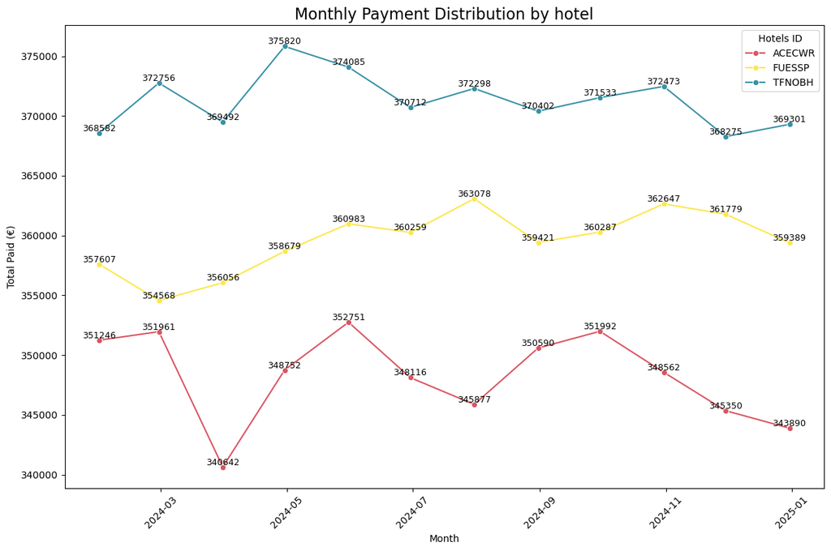

```python
# Collecting the data to visualize the total paid by the hotels
monthly_payment_by_hotel = emp_wages_wfc.groupby([pd.Grouper(key='Payment_date', freq='M'), 'hotel_id_x']).agg({
    'total_paid_NH': 'sum',
}).reset_index()

# Creating the lineplot
plt.figure(figsize=(12, 8))
sns.lineplot(
    data=monthly_payment_by_hotel,
    x='Payment_date',
    y='total_paid_NH',
    hue='hotel_id_x',
    palette=['#DB5461', '#FDE74C', '#3891A6'],
    marker='o',
    )

for hotel in monthly_payment_by_hotel['hotel_id_x'].unique():
    hotel_data = monthly_payment_by_hotel[monthly_payment_by_hotel['hotel_id_x'] == hotel]
    for x, y in zip(hotel_data['Payment_date'], hotel_data['total_paid_NH']):
        plt.text(x, y, f'{y:.0f}', fontsize=9, ha='center', va='bottom')

plt.title('Monthly Payment Distribution by hotel', fontsize=16)
plt.xlabel('Month')
plt.ylabel('Total Paid (€)')
plt.xticks(rotation=45)
plt.legend(title='Hotels ID')
plt.tight_layout()

plt.show()
```

According to our data, **Ocean Breeze Haven** is the hotel that pays more in salaries. **Sandy Shores Park** comes next, and this hotel likewise pays more consistently. Last but not least is **Coral Wave Resort**, which has the lowest payments and has seen a decline since the year started.

To see the total amount of wages paid by the three hotels, let's aggregate all the data. First, the total paid for *nomal hours* and later, the total paid for *overtime hours*.

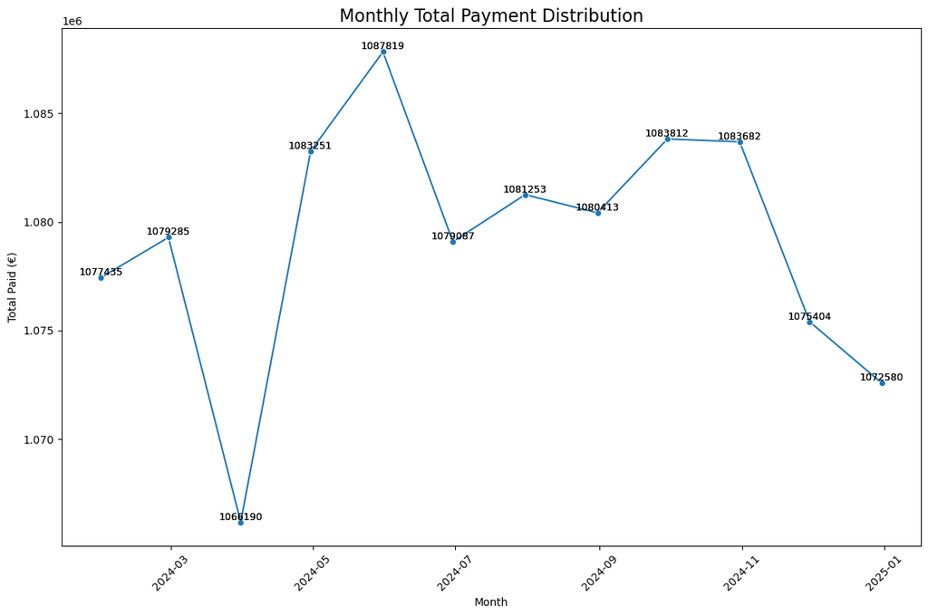

```python
# Collecting the data to visualize the total paid by the hotels in normal hours
monthly_payment = emp_wages_wfc.groupby(pd.Grouper(key='Payment_date', freq='M')).agg({'total_paid_NH': 'sum'}).reset_index()

# Creating the lineplot
plt.figure(figsize=(12, 8))
sns.lineplot(
    data=monthly_payment,
    x='Payment_date',
    y='total_paid_NH',
    palette=['#3891A6'],
    marker='o',
    )

for hotel in monthly_payment:
    hotel_data = monthly_payment
    for x, y in zip(hotel_data['Payment_date'], hotel_data['total_paid_NH']):
        plt.text(x, y, f'{y:.0f}', fontsize=9, ha='center', va='bottom')

plt.title('Monthly Total Payment Distribution', fontsize=16)
plt.xlabel('Month')
plt.ylabel('Total Paid (€)')
plt.xticks(rotation=45)
plt.tight_layout()

plt.show()
```

The data shows that March registered the lowest payment in salaries with a total of *€ 1.066.190* and the highest paid in salaries is May with a total *€ 1.087.819*

Let's see what the overtime hours have to show us.

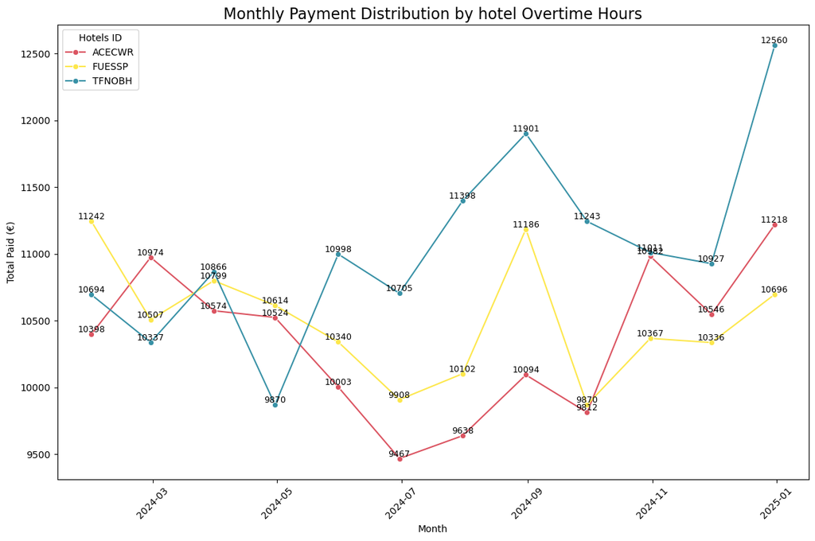

```python
# Collecting the data to visualize the total paid by the hotels in Over Time hours
monthly_payment_by_hotel_ot = emp_wages_wfc.groupby([pd.Grouper(key='Payment_date', freq='M'), 'hotel_id_x']).agg({
    'total_paid_OT': 'sum',
}).reset_index()

# Creating the lineplot
plt.figure(figsize=(12, 8))
sns.lineplot(
    data=monthly_payment_by_hotel_ot,
    x='Payment_date',
    y='total_paid_OT',
    hue='hotel_id_x',
    palette=['#DB5461', '#FDE74C', '#3891A6'],
    marker='o',
    )

for hotel in monthly_payment_by_hotel_ot['hotel_id_x'].unique():
    hotel_data = monthly_payment_by_hotel_ot[monthly_payment_by_hotel_ot['hotel_id_x'] == hotel]
    for x, y in zip(hotel_data['Payment_date'], hotel_data['total_paid_OT']):
        plt.text(x, y, f'{y:.0f}', fontsize=9, ha='center', va='bottom')

plt.title('Monthly Payment Distribution by hotel Overtime Hours', fontsize=16)
plt.xlabel('Month')
plt.ylabel('Total Paid (€)')
plt.xticks(rotation=45)
plt.legend(title='Hotels ID')
plt.tight_layout()

plt.show()
```

Now is time to visualize the sum of the total paid on overtime hours for the three hotels.

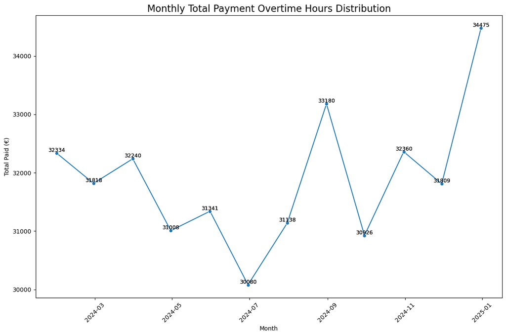

```python
# Collecting the data to visualize the total paid between the hotels in Over Time hours
monthly_payment_ot = emp_wages_wfc.groupby(pd.Grouper(key='Payment_date', freq='M')).agg({'total_paid_OT': 'sum'}).reset_index()

# Creating the lineplot
plt.figure(figsize=(12, 8))
sns.lineplot(
    data=monthly_payment_ot,
    x='Payment_date',
    y='total_paid_OT',
    palette=['#3891A6'],
    marker='o',
    )

for hotel in monthly_payment_ot:
    hotel_data = monthly_payment_ot
    for x, y in zip(hotel_data['Payment_date'], hotel_data['total_paid_OT']):
        plt.text(x, y, f'{y:.0f}', fontsize=9, ha='center', va='bottom')

plt.title('Monthly Total Payment Overtime Hours Distribution', fontsize=16)
plt.xlabel('Month')
plt.ylabel('Total Paid (€)')
plt.xticks(rotation=45)
plt.tight_layout()

plt.show()
```

The data indicates that the total amount paid for extra hours decreased between January and June, reaching the minimum payout of **€30,080**. From then on, the total amount of overtime payments began to rise, peaking at **€34,475** in December.

*It is important to investigate whether the growth is seasonal or occurred due to a lack of personnel for the operation.*

Let's continue with our analysis. Now is time to filter our data by *Departments*.

```
Payment_month               January     February        March        April  \
Department
3R                       23788.0375   25218.5450   24951.7950   24210.7150
Animation                75262.0575   76100.8650   76694.5050   76639.7000
Bar_Restaurant          243748.3900  242044.1000  242306.9700  240518.0475
Floors_Laundry          234890.1075  237591.0725  235397.6600  238962.1675
Kitchen                 239475.5400  241929.8825  235661.5000  238551.6150
Other                    56590.5275   56225.5650   52591.7025   57435.8825
Reception_Reservations   82443.4525   81381.3025   82415.5650   85662.1550
SPA                      39957.4525   39382.4850   39308.5225   40429.6000
Technical_Services       80320.3650   77896.0925   76148.3950   78421.3475

Payment_month                   May         June         July       August  \
Department
3R                       24819.8750   24660.5525   24729.6650   23719.4100
Animation                78262.2675   76263.5825   76848.9775   77691.9075
Bar_Restaurant          244199.9250  239861.8425  240631.7800  239864.0250
Floors_Laundry          238797.0250  237845.6975  240466.8800  239030.5525
Kitchen                 240551.9975  241796.5075  240427.8375  241041.1200
Other                    56404.0450   53803.7175   57132.7575   55454.1725
Reception_Reservations   82340.1475   83753.6800   82323.1725   82068.7900
SPA                      41678.9600   40275.8550   38823.7650   40522.9625
Technical_Services       78530.9575   77630.7975   77634.9200   80792.2700

Payment_month             September      October     November     December
Department
3R                       25311.1800   23944.4500   25051.4625   24647.7000
Animation                76688.2000   76275.2225   75959.2450   77702.8200
Bar_Restaurant          242982.3325  241844.7650  242111.2725  241070.7050
Floors_Laundry          236468.5400  237566.8225  234701.4425  235476.7150
Kitchen                 243247.1425  244014.4125  240852.4550  237833.5725
Other                    55472.8450   56411.8050   52620.3175   56609.6850
Reception_Reservations   82405.6225   82912.2050   82731.7850   82755.0650
SPA                      40678.4050   39915.7425   40930.6050   40284.5850
Technical_Services       78041.1075   79675.5575   79038.0250   77462.7450
```

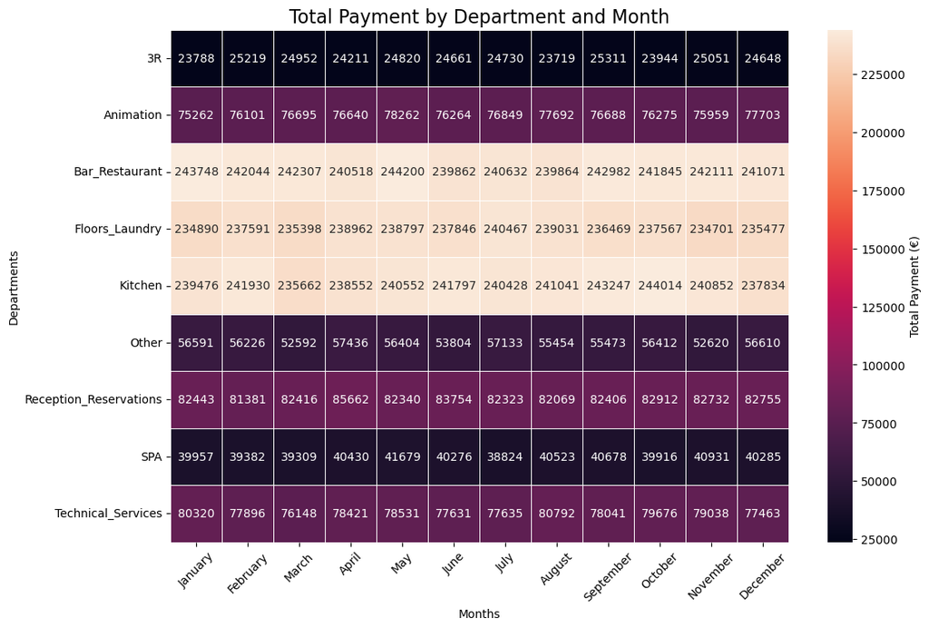

```python
# Let's check the total payment by department and month
emp_wages_wfc['Payment_month'] = emp_wages_wfc['Payment_date'].dt.strftime('%B')

month_order = ['January', 'February', 'March', 'April', 'May', 'June',
               'July', 'August', 'September', 'October', 'November', 'December']


heatmap_pivot = emp_wages_wfc.pivot_table(index='Department', columns='Payment_month', values='Total_Payment', aggfunc='sum')
heatmap_pivot = heatmap_pivot.reindex(columns=month_order)
print(heatmap_pivot)

# Creating the heatmap
plt.figure(figsize=(12, 8))
sns.color_palette("mako", as_cmap=True)
sns.heatmap(heatmap_pivot, annot=True, fmt=".0f", cbar_kws={'label': 'Total Payment (€)'}, linewidth=.5)

plt.title('Total Payment by Department and Month', fontsize=16)
plt.ylabel('Departments')
plt.xlabel('Months')
plt.xticks(rotation=45)
plt.show()
```

When we analyze the data filtered by *Departments* we can visualize that **"Bar & Restaurant", "Floors & Laundry"**, and **"Kitchen"**, are the three departments that demand the largest part of the budget. Then **"Technical Services", "Reception & Reservations"**, and **"Animation"** are the following departments with a middle-low demand of the budget. All the rest share a small part of the budget.

For the last, let's figure out the average salary that the hotels are paying in general and filtered by departments

```python
# Average Salary
avg_salary = emp_wages_wfc['Total_Payment'].mean().round(2)
avg_salary_by_hotel = emp_wages_wfc.groupby('hotel_id_x')['Total_Payment'].mean().round(2)
avg_salary_by_department = emp_wages_wfc.groupby('Department')['Total_Payment'].mean().round(2)


avg_salary_by_hotel.index = avg_salary_by_hotel.index.map(lambda x: f"{x} ({hotel_names[x]})")
avg_salary_by_hotel.index.name = None
avg_salary_by_department.index.name = None

print('The Total Average Salary is: €', avg_salary, '\n\n',
      'The Average Salary by Hotel is: ', '\n',avg_salary_by_hotel, '\n\n',
      'The Average Salary by Department is: ', '\n', avg_salary_by_department)
```

```
The Total Average Salary is: € 2134.15

 The Average Salary by Hotel is:
 ACECWR (Coral Wave Resort)     2108.51
FUESSP (Sandy Shores Park)     2162.40
TFNOBH (Ocean Breeze Haven)    2131.51
Name: Total_Payment, dtype: float64

 The Average Salary by Department is:
 3R                        2235.25
Animation                 2130.53
Bar_Restaurant            2066.37
Floors_Laundry            2063.18
Kitchen                   2072.83
Other                     3086.82
Reception_Reservations    2236.92
SPA                       2232.36
Technical_Services        2120.70
Name: Total_Payment, dtype: float64
```

5. Loading the data to MySQL

Let's start working with **MySQL**. We are required to connect to MySQL and later create a cursor to work with the queries.

```python
# Let's create the connection to MySQL
try:

    db = mysql.connector.connect(
        host = "localhost",
        user = "root",
        password = dbpass
    )
    print("Connection established")
    # Creating the cursor to execute queries
    cursor = db.cursor()

except mysql.connector.Error as err:
    print("An error occurred: ", err)
```

```
Connection established
```

```python
# Creating a enginge connection
hostname = "localhost"
database = "hrhotelpa"
username = "root"
password = dbpass

engine = create_engine("mysql+pymysql://{user}:{pw}@{host}/{db}".format(host=hostname, db=database, user=username, pw=password))
```

```python
# Add the databases to MySQL
# df_rawht.to_sql('Hotels', engine, if_exists='append', index=False)
# df_rawemp.to_sql('Employees', engine, if_exists='append', index=False)
# df_rawhtcomp.to_sql('Hotel_Composition', engine, if_exists='append', index=False)
# df_rawworkforce.to_sql('Workforce_Composition', engine, if_exists='append', index=False)
# df_rawempwages.to_sql('Employees_Wages', engine, if_exists='append', index=False)
```

Now... that all the data have been uploaded to our MySQL database, it's time to close our connection.

```python
cursor.close()
db.close()
```